# What is Ecology in the 21st Century?

## About me: A diverse ecologist

- **Plant Ecologist**
  - climate change
  - physiology
  - evolution
- **Ecosystem Ecologist**
  - climate change
  - fire ecology
- **Shepherd Research:**
  - urban tree ecology
  - aquaponics at Tabler Farm

[figure not shown]

## This semester we will practice being a modern ecologist

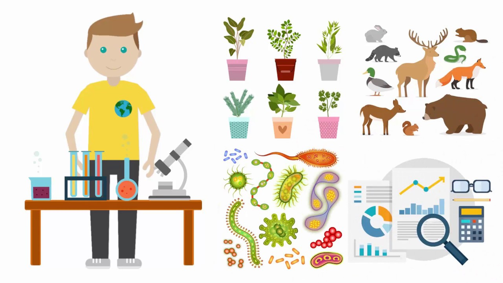

## This semester we will ….

- **Learn ecology**
  - Lecture
  - Journal club
- **Do Ecology**
  - Labs + fieldwork + data exercises
- **Contribute to ecological experiments**
- **Apply ecology**
  - A C.U.R.E for Invasions

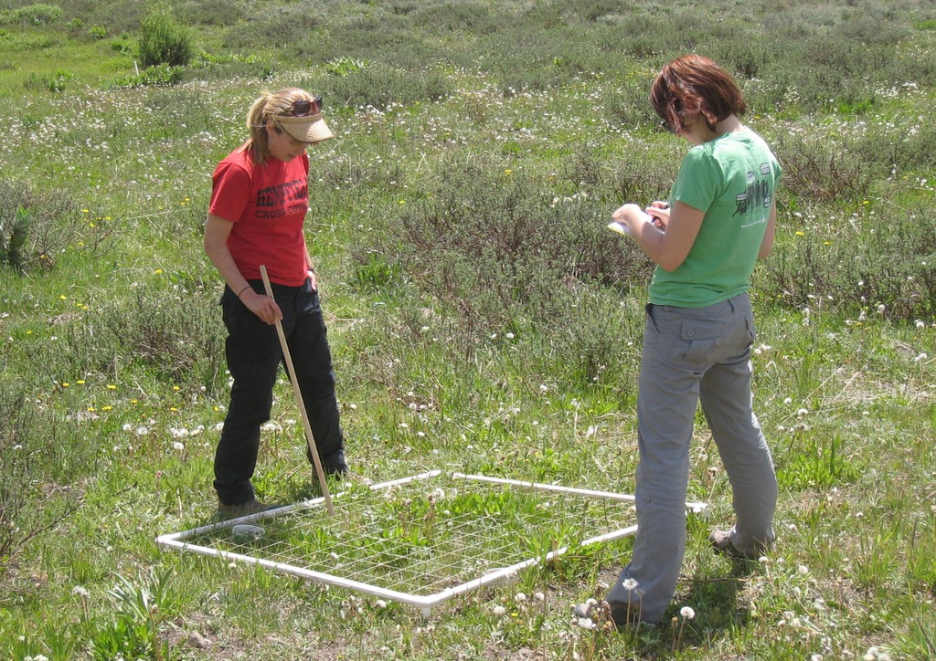

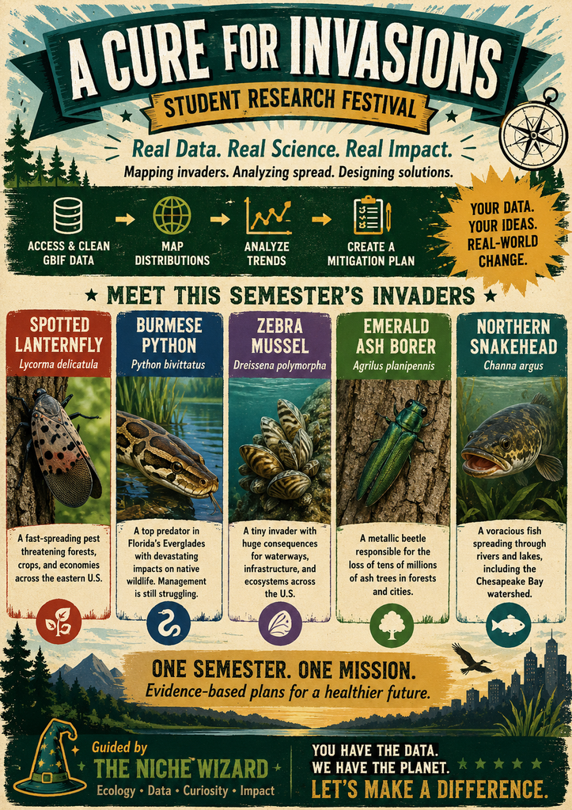

## FALL 2026: A C.U.R.E for Invasions

- **A C.U.R.E. (Course-based Undergraduate Research Experience) is a class where students do real, original scientific research or creative inquiry as part of the regular curriculum**
- **You will need to build the skills to solve/mitigate the issues of your invasive species**
- **Find data → Clean data → Analyze → Map → Research management → Communicate → Build an Action Plan**
  - Real tools. Real data. Real ecological problem.
- **Each Friday (+ a little more) you will learn new applied skills to eventually mitigate your species**
  - These skills are transferable on the job market (your resume)
  - Create a portfolio of products that you can use in an internship, job, or graduate-school interview.

## What is ecology (textbook definition)?

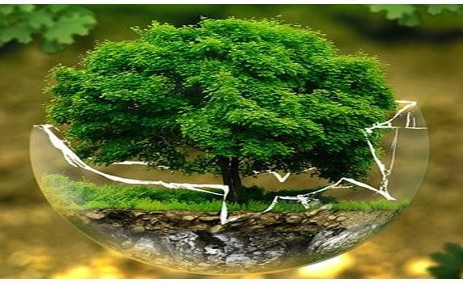

- **Ecology has a few big themes:**
- **study of the interactions between living organisms and their physical environment**
  - Includes living and non-living components
- **(1) Distribution and abundance of organisms**
- **(2) Interactions among organisms**
- **(3) Transformation and flux of energy and matter**

## Are humans a part of ecology? YES!

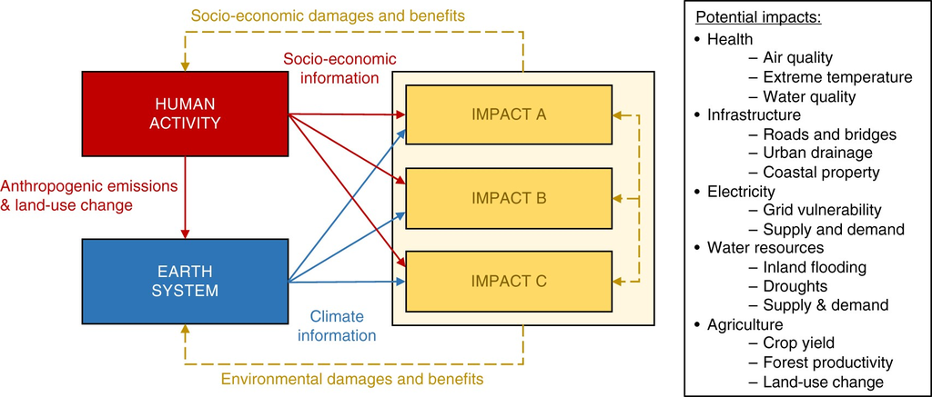

## Ecology concepts span many scales, including time

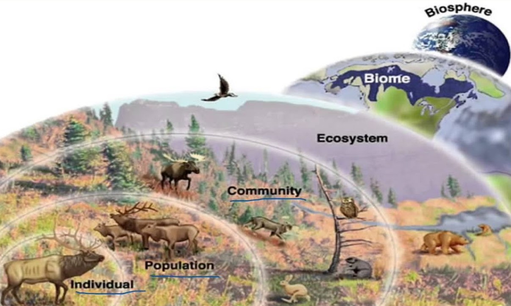

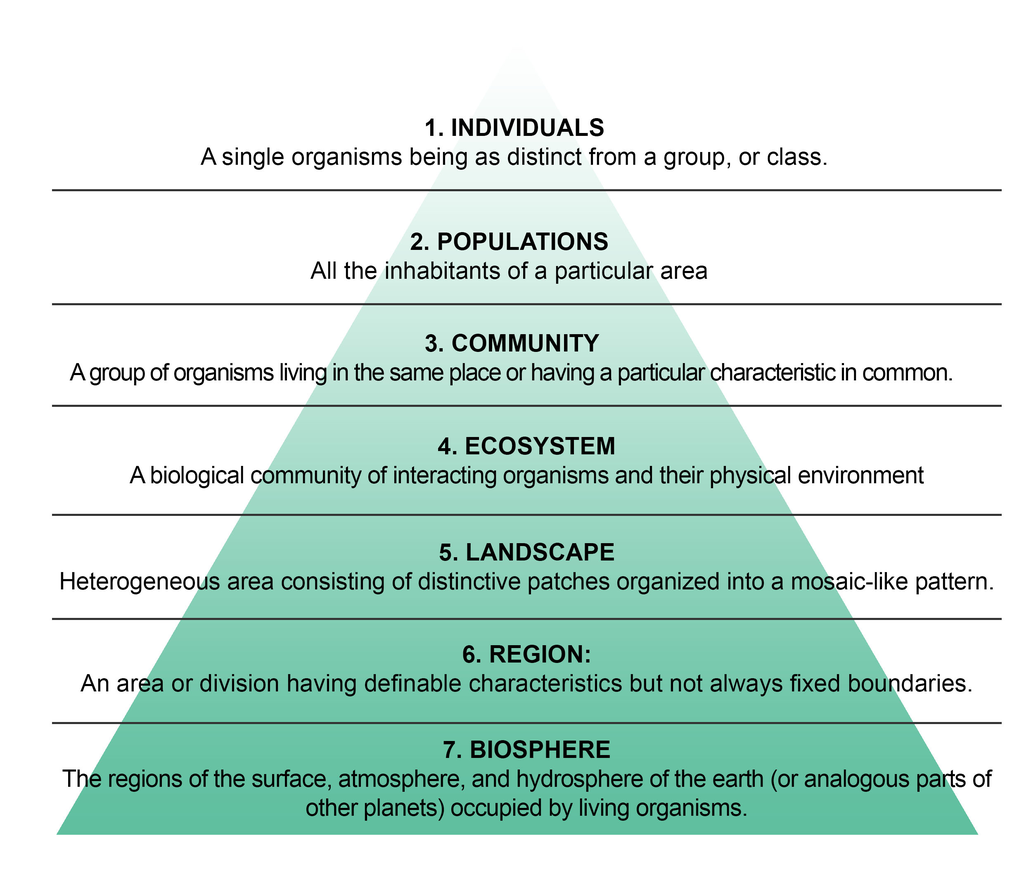

## Ecologist try to understand, explain, and predict

**Ecological questions rarely have one simple answer**

[figure not shown]

**Ecological processes develop over long time periods**

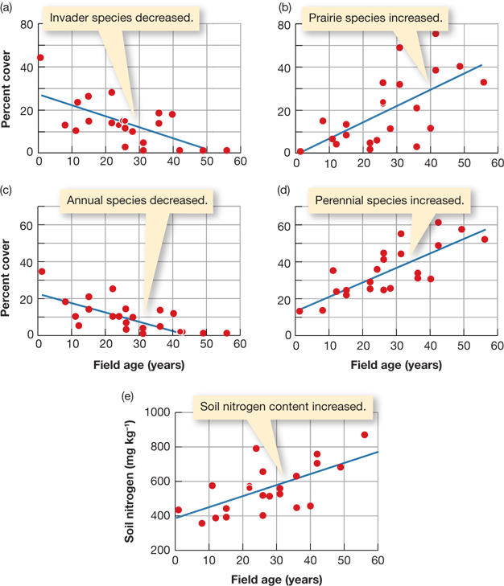

## What is the central need for ecology?

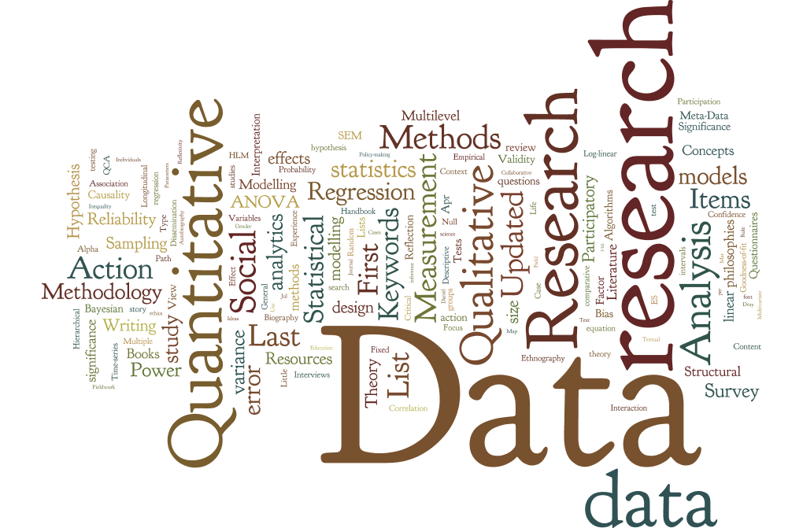

## Class Warning: We will be moving up Bloom’s ladder

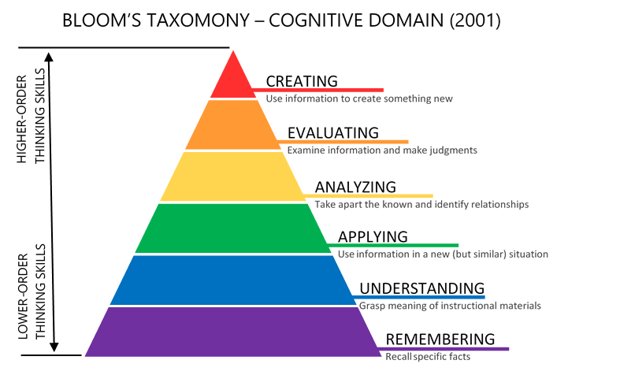

## For Journal Club this week….

- **Read “100 articles every ecologist should read”**
  - article and cheat sheet on Brightspace
- **Take specific notes**
  - What ecological themes are common?
  - Do you feel any themes are missing?
  - Is there a take home message?
  - Is there anything you don’t understand?
  - *Complete and submit your reflection in person before class starts*
- **Pay attention to little details**
  - Are there any patterns you see?
  - Do you detect any issues?

[figure not shown]

## Journal Club warning…

- **If there is one thing that I know in life it is plants !**
- **If there are two things that I know, the second is if you have read the paper.**
  - It is obvious to me when you are not prepared for the readings.
  - I can easily distinguish between misunderstanding and poor preparation!
  - I expect you to have a copy of the paper and notes in class (phone is not acceptable)
- **I take this very seriously and you will NOT do well in this class if you do not participate**
  - The reflection is required to participate in Journal Club. No points will be rewarded for late submission

[figure not shown]

## Keep the ‘Pot of Doom’ locked away

- **At the start of Journal Club one name will be drawn**
- **Student will be responsible for 2 things:**
  - 1 minute brief on what the paper addresses (theme, species, issue, etc.)
  - Definition or explanation of a science word or concept from the paper you did not know (so you had to look it up)

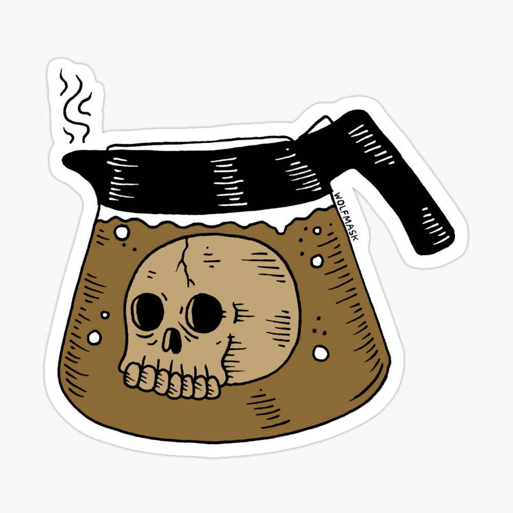

## Lab tomorrow….

- **Meet in lab (Byrd 210)**
- **C.U.R.E**
  - Get your species and first learning group
  - Practice research question and hypothesis writing
  - Discuss why invasive species matter in ecology
- **Walk to Carl Bell arboretum**
  - Visit the Deer exclosure experiment
  - Start a decomposition experiment
  - Wear field appropriate clothes